# McDonald’s Case Study

# Case Study: Fast Food

The purpose of this case study is to offer another illustration of market segmentation analysis using a different empirical data set.

This data set was collected originally for the purpose of comparing the validity of a range of different answer formats in survey research investigating brand image. Descriptions of the data are available in Dolnicar and Leisch (2012), Dolnicar and Grün (2014), and Grün and Dolnicar (2016). Package MSA contains the sections of the data used in this case study.

For this case study, imagine that you are McDonald’s, and you would want to know if consumer segments exist that have a distinctly different image of McDonald’s. Understanding such systematic differences of brand perceptions by market segments informs which market segments to focus on, and what messages to communicate to them. We can choose to focus on market segments with a positive perception, and strengthen the positive perception. Or we can choose to focus on a market segment that currently perceives McDonald’s in a negative way. In this case, we want to understand the key drivers of the negative perception, and modify them.

## 1. Step 1: Deciding (not) to Segment

McDonald’s can take the position that it caters to the entire market and that there is no need to understand systematic differences across market segments. Alternatively, McDonald’s can take the position that, despite their market power, there is value in investigating systematic heterogeneity among consumers and harvest these differences using a differentiated marketing strategy.

## 2. Step 2: Specifying the Ideal Target Segment

McDonald’s management needs to decide which key features make a market seg- ment attractive to them. In terms of knock-out criteria, the target segment or target segments must be homogeneous (meaning that segment members are similar to one another in a key characteristic), distinct (meaning that members of the segments differ substantially from members of other segments in a key characteristic), large enough to justify the development and implementation of a customised marketing mix, matching the strengths of McDonald’s (meaning, for example, that they must be open to eating at fast food restaurants rather than rejecting them outright), identifiable (meaning that there must be some way of spotting them among other consumers) and, finally, reachable (meaning that channels of communication and distribution need to exist which make it possible to aim at members of the target segment specifically).

In terms of segment attractiveness criteria, the obvious choice would be a segment that has a positive perception of McDonald’s, frequently eats out and likes fast food. But McDonald’s management could also decide that they not only wish to solidify their position in market segments in which they already hold high market shares, but rather wish to learn more about market segments which are currently not fond of McDonald’s; try to understand which perceptions are responsible for this; and attempt to modify those very perceptions.

Given that the fast food data set in this case study contains very little information beyond people’s brand image of McDonald’s, the following attractiveness criteria will be used: liking McDonald’s and frequently eating at McDonald’s. These segment attractiveness criteria represent key information in Step 8 where they inform target segment selection.

## 3. Step 3: Collecting Data

The data set contains responses from 1453 adult Australian consumers relating to their perceptions of McDonald’s with respect to the following attributes: YUMMY , CONVENIENT , SPICY , FATTENING , GREASY , FAST , CHEAP , TASTY , EXPENSIVE , HEALTHY ,and DISGUSTING .Theseattributesemergedfromaqualitativestudycon- ducted in preparation of the survey study. For each of those attributes, respondents provided either a YES response (indicating that they feel McDonald’s possesses this attribute), or a NO response (indicating that McDonald’s does not possess this attribute).

In addition, respondents indicated their AGE and GENDER . Had this data been collected for a real market segmentation study, additional information – such as details about their dining out behaviour, and their use of information channels – would have been collected to enable the development of a richer and more detailed description of each market segment.

## 4. Step 4: Exploring Data

First we explore the key characteristics of the data set by loading the data set and inspecting basic features such as the variable names, the sample size, and the first three rows of the data:

```r
load("mcdonalds.Rdata")
head(mcdonalds, 3)
```

|  | yummy | convenient | spicy | fattening | greasy | fast | cheap | tasty | expensive | healthy | disgusting | Like | Age | VisitFrequency | Gender |
| --- | --- | --- | --- | --- | --- | --- | --- | --- | --- | --- | --- | --- | --- | --- | --- |
| 1 | No | Yes | No | Yes | No | Yes | Yes | No | Yes | No | No | -3 | 61 | Every three months | Female |
| 2 | Yes | Yes | No | Yes | Yes | Yes | Yes | Yes | Yes | No | No | +2 | 51 | Every three months | Female |
| 3 | No | Yes | Yes | Yes | Yes | Yes | No | Yes | Yes | Yes | No | +1 | 62 | Every three months | Female |

As we can see from the output, the first respondent believes that McDonald’s is not yummy, convenient, not spicy, fattening, not greasy, fast, cheap, not tasty, expensive, not healthy and not disgusting. This same respondent does not like McDonald’s (rating of −3), is 61 years old, eats at McDonald’s every three months and is female.

This quick glance at the data shows that the segmentation variables (perception of McDonald’s) are verbal, not numeric. This means that they are coded using the words YES and NO . This is not a suitable format for segment extraction. We need numbers, not words. To get numbers, we store the segmentation variables in a separate matrix, and convert them from verbal YES / NO to numeric binary.

First we extract the first eleven columns from the data set because these columns contain the segmentation variables, and convert the data to a matrix. Then we identify all YES entries in the matrix. This results in a logical matrix with entries TRUE and FALSE. Adding 0 to the logical matrix converts TRUE to 1, and FALSE to 0. We check that we transformed the data correctly by inspecting the average value of each transformed segementation variable.

```r
MD_x <- mcdonalds %>%
  # select only yes no
  select(1:11) %>%
  # Convert to 1/0
  mutate_all(~if_else(.x=="Yes",1,0))
MD_x
```

| yummy | convenient | spicy | fattening | greasy | fast | cheap | tasty | expensive | healthy | disgusting |
| --- | --- | --- | --- | --- | --- | --- | --- | --- | --- | --- |
| 0 | 1 | 0 | 1 | 0 | 1 | 1 | 0 | 1 | 0 | 0 |
| 1 | 1 | 0 | 1 | 1 | 1 | 1 | 1 | 1 | 0 | 0 |
| 0 | 1 | 1 | 1 | 1 | 1 | 0 | 1 | 1 | 1 | 0 |
| 1 | 1 | 0 | 1 | 1 | 1 | 1 | 1 | 0 | 0 | 1 |
| 0 | 1 | 0 | 1 | 1 | 1 | 1 | 0 | 0 | 1 | 0 |
| 1 | 1 | 0 | 1 | 0 | 1 | 1 | 1 | 0 | 0 | 0 |
| 1 | 1 | 1 | 1 | 0 | 1 | 0 | 1 | 1 | 1 | 0 |
| 1 | 1 | 0 | 1 | 1 | 1 | 1 | 1 | 0 | 0 | 0 |
| 0 | 0 | 0 | 1 | 1 | 0 | 0 | 0 | 1 | 0 | 1 |
| 1 | 1 | 0 | 1 | 1 | 1 | 0 | 1 | 1 | 0 | 0 |

[output cut: 1443 more lines]

```r
# Summary of frequency
MD_x %>% map_dbl(mean)
```

```
##      yummy convenient      spicy  fattening     greasy       fast      cheap      tasty  expensive
## 0.55264969 0.90777701 0.09359945 0.86717137 0.52649690 0.90020647 0.59876118 0.64418445 0.35788025
##    healthy disgusting
## 0.19889883 0.24294563
```

The average values of the transformed binary numeric segmentation variables indicate that about half of the respondents (55%) perceive McDonald’s as YUMMY , 91% believe that eating at McDonald’s is CONVENIENT , but only 9% think that McDonald’s food is SPICY .

Another way of exploring data initially is to compute a principal components analysis, and create a perceptual map. A perceptual map offers initial insights into how attributes are rated by respondents and, importantly, which attributes tend to be rated in the same way. Principal components analysis is not computed to reduce the number of variables. This approach – also referred to as factor-cluster analysis – is inferior to clustering raw data in most instances (Dolnicar and Grün 2008). Here, we calculate principal components because we use the resulting components to rotate and project the data for the perceptual map. We use unstandardised data because our segmentation variables are all binary.

```r
MD_pca <- prcomp(MD_x)
summary(MD_pca)
```

```
## Importance of components:
##                           PC1    PC2    PC3    PC4     PC5    PC6     PC7     PC8     PC9    PC10
## Standard deviation     0.7570 0.6075 0.5046 0.3988 0.33741 0.3103 0.28970 0.27512 0.26525 0.24884
## Proportion of Variance 0.2994 0.1928 0.1331 0.0831 0.05948 0.0503 0.04385 0.03955 0.03676 0.03235
## Cumulative Proportion  0.2994 0.4922 0.6253 0.7084 0.76787 0.8182 0.86201 0.90156 0.93832 0.97068
##                           PC11
## Standard deviation     0.23690
## Proportion of Variance 0.02932
## Cumulative Proportion  1.00000
```

Results from principal components analysis indicate that the first two components capture about 50% of the information contained in the segmentation variables. The following command returns the factor loadings:

```r
print(MD_pca, digits = 1)
```

```
## Standard deviations (1, .., p=11):
##  [1] 0.8 0.6 0.5 0.4 0.3 0.3 0.3 0.3 0.3 0.2 0.2
##
## Rotation (n x k) = (11 x 11):
##               PC1   PC2   PC3    PC4    PC5   PC6   PC7   PC8    PC9   PC10   PC11
## yummy       0.477 -0.36  0.30 -0.055 -0.308  0.17 -0.28  0.01 -0.572  0.110  0.045
## convenient  0.155 -0.02  0.06  0.142  0.278 -0.35 -0.06 -0.11  0.018  0.666 -0.542
## spicy       0.006 -0.02  0.04 -0.198  0.071 -0.36  0.71  0.38 -0.400  0.076  0.142
## fattening  -0.116  0.03  0.32  0.354 -0.073 -0.41 -0.39  0.59  0.161  0.005  0.251
## greasy     -0.304  0.06  0.80 -0.254  0.361  0.21  0.04 -0.14  0.003 -0.009  0.002
## fast        0.108  0.09  0.06  0.097  0.108 -0.59 -0.09 -0.63 -0.166 -0.240  0.339
## cheap       0.337  0.61  0.15 -0.119 -0.129 -0.10 -0.04  0.14 -0.076 -0.428 -0.489
## tasty       0.472 -0.31  0.29  0.003 -0.211 -0.08  0.36 -0.07  0.639 -0.079  0.020
## expensive  -0.329 -0.60 -0.02 -0.068 -0.003 -0.26 -0.07  0.03 -0.067 -0.454 -0.490
## healthy     0.214 -0.08 -0.19 -0.763  0.288 -0.18 -0.35  0.18  0.186  0.038  0.158
## disgusting -0.375  0.14  0.09 -0.370 -0.729 -0.21 -0.03 -0.17  0.072  0.290 -0.041
```

The loadings indicate how the original variables are combined to form principal components. Loadings guide the interpretation of principal components. In our example, the two segmentation variables with the highest loadings (in absolute terms) for principal component 2 are CHEAP and EXPENSIVE , indicating that this principal component captures the price dimension. We project the data into the principal component space with predict. The following commands rotate and project consumers (in grey) into the first two principal components, plot them and add the rotated and projected original segmentation variables as arrows:

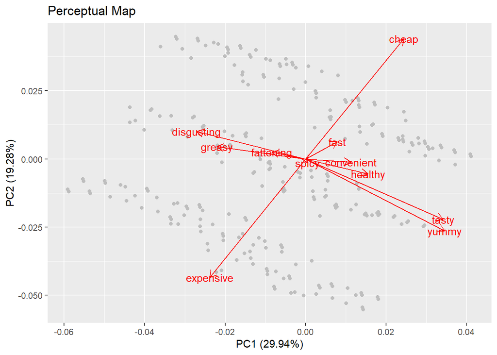

Figure 1

```r
autoplot(MD_pca, col = "grey", loadings=TRUE, loadings.label=TRUE, ) + ggtitle("Perceptual Map")
```

Figure 1 shows the resulting perceptual map. The attributes CHEAP and EXPENSIVE play a key role in the evaluation of McDonald’s, and these two attributes are assessed quite independently of the others.

The remaining attributes align with what can be interpreted as positive versus negative perceptions: FATTENING , DISGUSTING and GREASY point in the same direction in the perceptual chart, indicating that respondents who view McDonald’s as FATTENING , DISGUSTING are also likely to view it as GREASY .

In the opposite direction are the positive attributes FAST , CONVENIENT , HEALTHY , as well as TASTY and YUMMY . The observations along the EXPENSIVE versus CHEAP axis cluster around three values:

1. a group of consumers at the top around the arrow pointing to CHEAP
2. a group of respondents at the bottom around the arrow pointing to EXPENSIVE
3. a group of respondents in the middle.

These initial exploratory insights represent valuable information for segment extraction. Results indicate that some attributes are strongly related to one another, and that the price dimension may be critical in differentiating between groups of consumers.

## 5. Step 5: Extracting Segments

Step 5 is where we extract segments. To illustrate a range of extraction techniques, we subdivide this step into three sections. In the first section, we will use standard k-means analysis. In the second section, we will use finite mixtures of binary distributions. In the third section, we will use finite mixtures of regressions.

### 5.1 Using k-Means

```r
set.seed(SEED) # For reproducibility
MD_km28 <- stepFlexclust(MD_x, 2:8, nrep = 20,
  verbose = FALSE)
MD_km28 <- relabel(MD_km28)
```

```r
show(MD_km28)
```

```
## stepFlexclust object of family 'kmeans'
##
## call:
## relabel(object = MD_km28)
##
##   iter converged  distsum
## 1   NA        NA 1971.170
## 2    6      TRUE 1716.489
## 3    8      TRUE 1556.643
## 4    8      TRUE 1450.781
## 5    8      TRUE 1348.632
## 6   10      TRUE 1278.324
## 7    7      TRUE 1215.812
## 8    8      TRUE 1192.883
```

We extract between two and eight segments because we do not know in advance what the best number of market segments is. If we calculate a range of solutions, we can compare them and choose the one which extracts segments containing similar consumers which are distinctly different from members of other segments.

We compare different solutions using a scree plot:

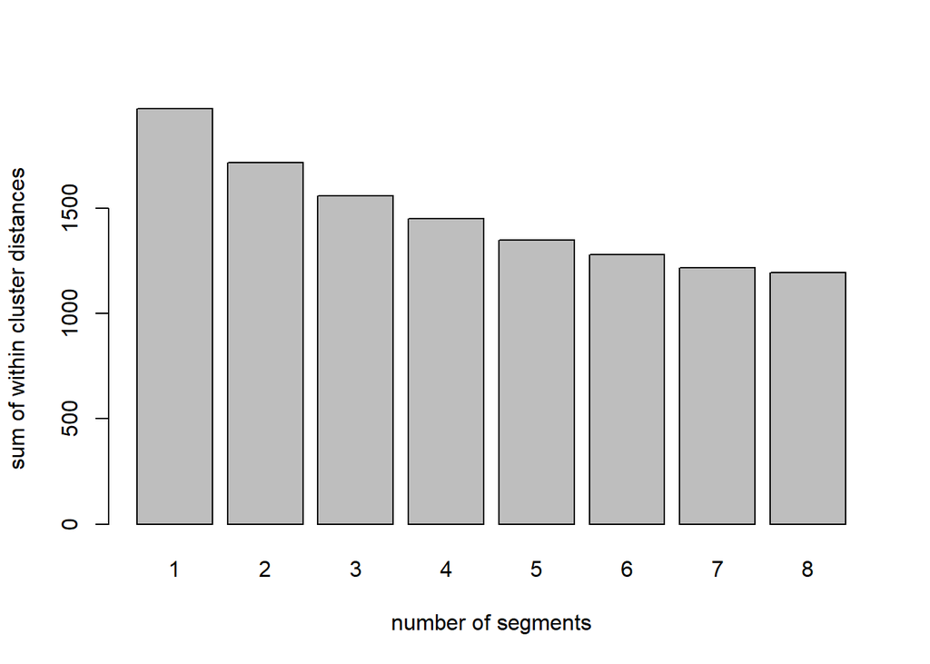

Fig 2

```r
plot(MD_km28, xlab = "number of segments")
```

where xlab specifies the label of the x-axis.

The scree plot in Fig.2 has no distinct elbow: the sum of distances within market segments drops slowly as the number of market segments increases. We expect the values to decrease because more market segments automatically mean that the segments are smaller and, as a consequence, that segment members are more similar to one another. But the much anticipated point where the sum of distances drops dramatically is not visible. This scree plot does not provide useful guidance on the number of market segments to extract.

A second approach to determining a good number of segments is to use stability-based data structure analysis. Stability-based data structure analysis also indicates whether market segments occur naturally in the data, or if they have to be artificially constructed. Stability-based data structure analysis uses stability across replications as criterion to offer this guidance. Imagine using a market segmentation solution which cannot be reproduced. Such a solution would give McDonald’s management little confidence in terms of investing substantial resources into a market segmentation strategy. Assessing the stability of segmentation solutions across repeated calculations (Dolnicar and Leisch 2010) ensures that unstable, random solutions are not used.

Global stability is the extent to which the same segmentation solution emerges if the analysis is repeated many times using bootstrap samples (randomly drawn subsets) of the data. Global stability is calculated using the following R code, which conducts the analysis for each number of segments (between two and eight) using 2 × 100 bootstrap samples (argument nboot) and ten random initialisations (argument nrep) of k-means for each sample and number of segments:

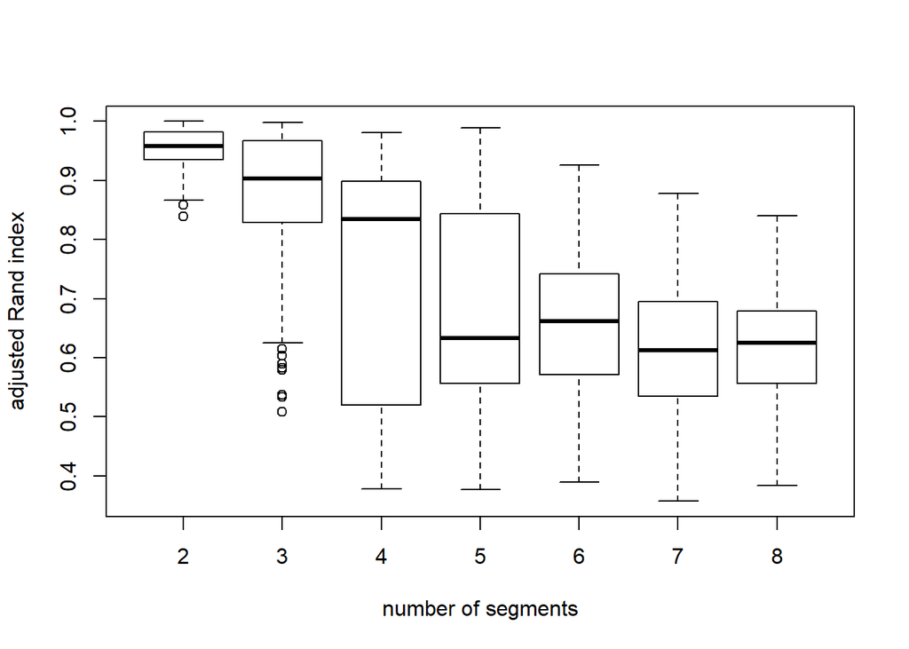

Fig 3

```r
set.seed(SEED)
MD_b28 <- bootFlexclust(MD_x, 2:8, nrep = 10, nboot = 100)
plot(MD_b28, xlab = "number of segments",
  ylab = "adjusted Rand index")
```

The vertical boxplots show the distribution of stability for each number of segments. The median is indicated by the fat black horizontal line in the middle of the box. Higher stability is better. Inspecting Fig.3 points to the two-, three- and four-segment solutions as being quite stable. However, the two- and three-segment solutions do not offer a very differentiated view of the market. Solutions containing a small number of segments typically lack the market insights managers are interested in. Once we increase the number of segments to five, average stability drops quite dramatically. The four- segment solution thus emerges as the solution containing the most market segments which can still be reasonably well replicated if the calculation is repeated multiple times.

We gain further insights into the structure of the four-segment solution with a gorge plot:

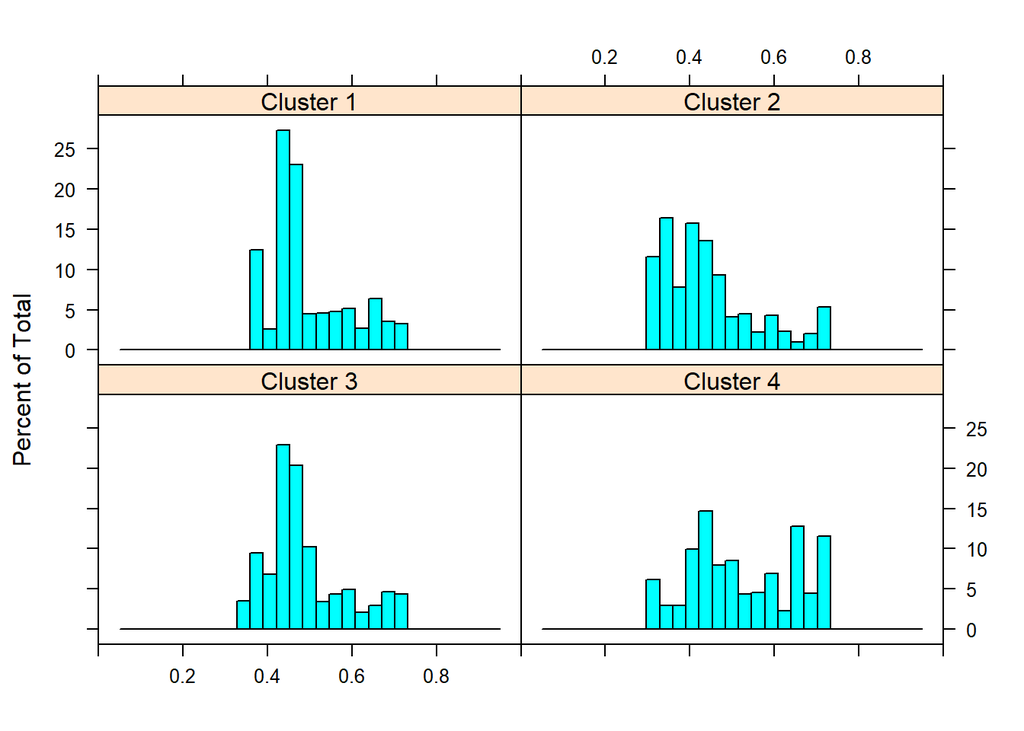

Fig 4

```r
histogram(MD_km28[["4"]], data = MD_x, xlim = 0:1)
```

None of the segments shown in Fig.4 is well separated from the other segments, and proximity to at least one other segment is present as indicated by the similarity values all being between 0.3 and 0.7. The analysis of global stability is based on a comparison of segmentation solu- tions with the same number of segments.

Another way of exploring the data before committing to the final market segmentation solution is to inspect how segment memberships change each time an additional market segment is added, and to assess segment level stability across solutions. This information is contained in the segment level stability across solutions (SLSA) plot created by `slsaplot(MD.km28)` and shown in Fig.5.

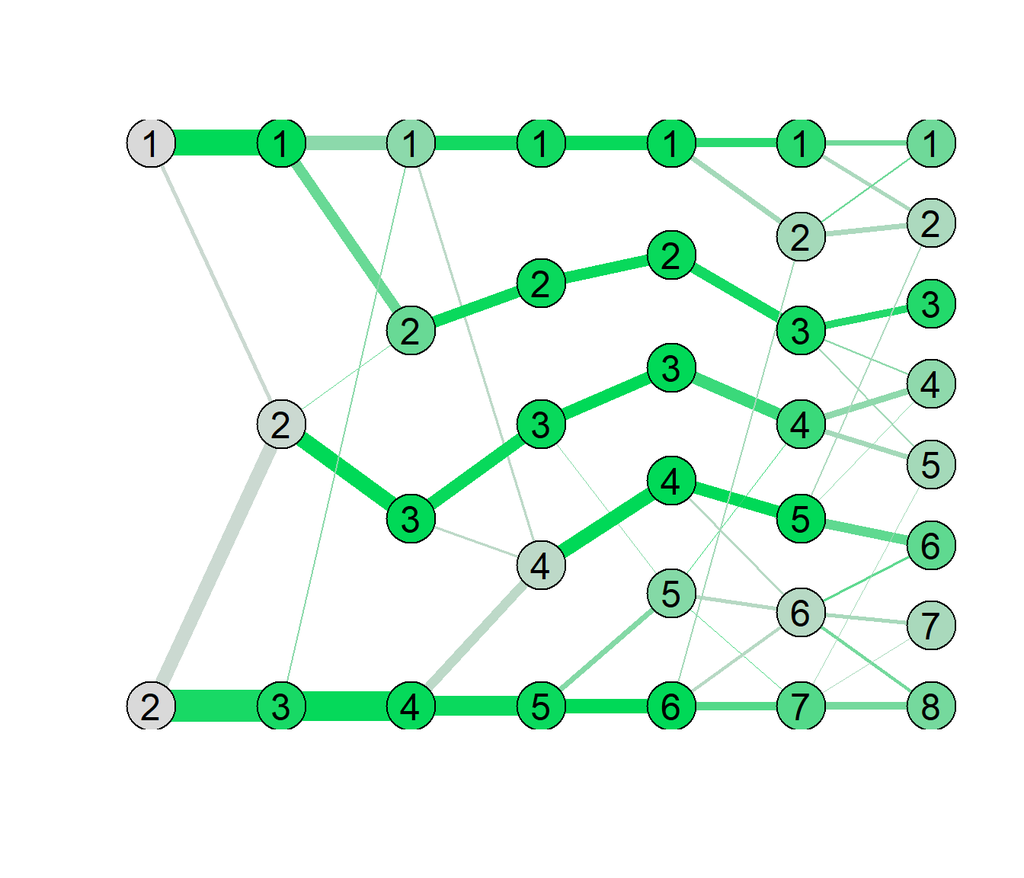

Fig 5

```r
slsaplot(MD_km28)
```

Thick green lines indicate that many members of the segment to the left of the line move across to the segment on the right side of the line. Segment 2 in the two-segment solution (in the far left column of the plot) remains almost unchanged until the four-segment solution, then it starts losing members. Looking at the segment level stability across solutions (SLSA) plot in Fig.5 in view of the earlier determination that the four-segment solution looks good, it can be concluded that segments 2, 3 and 4 are nearly identical to the corresponding segments in the three- and five-segment solution (from 3 segments to 5 segments, look at segments 1-2-2, 2-3-3, 3-4-5). They display high stability across solutions with different numbers of segments.

After this exploration, we select the four-segment solution and save it in an object of its own:

```r
MD_k4 <- MD_km28[["4"]]
```

By definition, global stability assesses the stability of a segmentation solution in its entirety. It does not investigate the stability of each market segment. We obtain the stability of each segment by calculating segment level stability within solutions (SLSW):

```r
MD_r4 <- slswFlexclust(MD_x, MD_k4)
```

We plot the result with limits 0 and 1 for the y-axis (ylim) and customised labels for both axes (xlab, ylab) using:

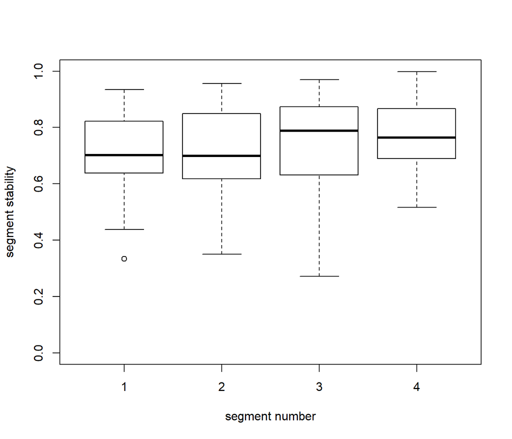

Fig 6

```r
plot(MD_r4, ylim = 0:1,
     xlab = "segment number",
     ylab = "segment stability")
```

### 5.2 Using Mixtures of Distributions

We calculate latent class analysis using a finite mixture of binary distributions. The mixture model maximises the likelihood to extract segments (as opposed to minimising squared Euclidean distance, as is the case for k-means). The call to `stepFlexmix()` extracts two to eight segments (k = 2:8) using ten random restarts of the EM algorithm (nrep), `model = FLXMCmvbinary()` for a segment-specific model consisting of independent binary distributions and no intermediate output about progress (verbose = FALSE).

```r
library("flexmix")
set.seed(1234) # for reproducibility
MD_m28 <- stepFlexmix(as.matrix(MD_x) ~ 1, k = 2:8, nrep = 10,
                      model = FLXMCmvbinary(), verbose = FALSE)
MD_m28
```

```
##
## Call:
## stepFlexmix(as.matrix(MD_x) ~ 1, model = FLXMCmvbinary(), k = 2:8, nrep = 10,
##     verbose = FALSE)
##
##   iter converged k k0    logLik      AIC      BIC      ICL
## 2   28      TRUE 2  2 -7610.848 15267.70 15389.17 15522.08
## 3   60      TRUE 3  3 -7311.520 14693.04 14877.89 15078.08
## 4   36      TRUE 4  4 -7111.133 14316.27 14564.49 14834.22
## 5   55      TRUE 5  5 -7011.202 14140.40 14452.01 14805.50
## 6   99      TRUE 6  6 -6956.257 14054.51 14429.49 14848.94
## 7   68      TRUE 7  7 -6900.196 13966.39 14404.75 14800.12
## 8  107      TRUE 8  8 -6872.602 13935.20 14436.94 14889.76
```

We plot the information criteria with a customised label for the y-axis to choose a suitable number of segments:

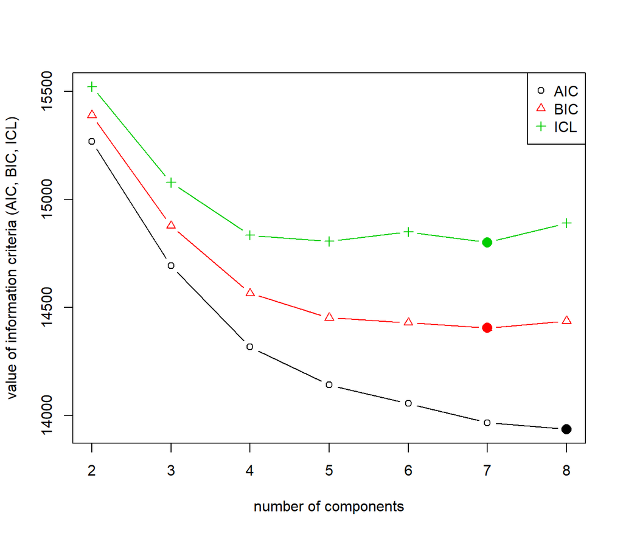

Fig 7

```r
plot(MD_m28,
  ylab = "value of information criteria (AIC, BIC, ICL)")
```

Figure 7 plots the information criteria values AIC, BIC and ICL on the y-axis for the different number of components (segments) on the x-axis. As can be seen,the values of all information criteria decrease quite dramatically until four components (market segments) are reached. If the information criteria are strictly applied based on statistical inference theory, the ICL recommends – by a small margin – the extraction of seven market segments. The BIC also points to seven market segments. The AIC values continue to decrease beyond seven market segments, indicating that at least eight components are required to suitably fit the data.

The visual inspection of Fig.7 suggests that four market segments might be a good solution if a more pragmatic point of view is taken; this is the point at which the decrease in the information criteria flattens visibly. We retain the four-component solution and compare it to the four-cluster k-means solution presented in Sect.5.1 using a cross-tabulation:

```r
MD_m4 <- getModel(MD_m28, which = "4")
table(kmeans = clusters(MD_k4), mixture = clusters(MD_m4))
```

```
##       mixture
## kmeans   1   2   3   4
##      1 281  12  34   5
##      2   0  34   0 196
##      3   0 310   1   0
##      4   0  23 557   0
```

The result becomes even more similar if the mixture model is initialised using the segment memberships of the k-means solution `MD_k4`:

```r
MD_m4a <- flexmix(as.matrix(MD_x) ~ 1,
                  cluster = clusters(MD_k4), # Initialized with MD_k4 solution
                  model = FLXMCmvbinary())
table(kmeans = clusters(MD_k4), mixture = clusters(MD_m4a))
```

```
##       mixture
## kmeans   1   2   3   4
##      1 282   5  11  34
##      2   0 196  34   0
##      3   0   0 309   2
##      4   0   0  23 557
```

This is interesting because all algorithms used to extract market segments are exploratory in nature. Typically, therefore, they find a local optimum or global optimum of their respective target function. The EM algorithm maximises the log- likelihood. The log-likelihood values for the two fitted mixture models obtained using the two different ways of initialisation are:

```r
logLik(MD_m4a)
```

```
## 'log Lik.' -7111.162 (df=47)
```

```r
logLik(MD_m4)
```

```
## 'log Lik.' -7111.133 (df=47)
```

indicating that the values are very close, with random initialisations leading to a slightly better result.

If two completely different ways of initialising the mixture model, namely:

1. ten random restarts and keeping the best
2. initialising the mixture model using the k-means solution

They both yield almost the same result, this gives more confidence that the result is a global optimum or a reasonably close approximation to the global optimum. It also is a re-assurance for the k-means solution, because the extracted segments are essentially the same. The fact that the two solutions are not identical is not of concern. Neither of the solutions is correct or incorrect. Rather, both of them need to be inspected and may be useful to managers.

### 5.3 Using Mixtures of Regression Models

Instead of finding market segments of consumers with similar perceptions of McDonald’s, it may be interesting to find market segments containing members whose love or hate for McDonald’s is driven by similar perceptions. This segmenta- tion approach would enable McDonald’s to modify critical perceptions selectively for certain target segments in view of improving love and reducing hate.

We extract such market segments using finite mixtures of linear regression models, also called latent class regressions. Here, the variables are not all treated in the same way. Rather, one dependent variable needs to be specified which captures the information predicted using the independent variables.

We choose as **dependent variable y** the degree to which consumers love or hate McDonald’s. The dependent variable contains responses to the statement **I LIKE MCDONALDS**. It is measured on an 11-point scale with endpoints labelled **I LOVE IT !** and **I HATE IT !**. The **independent variables x** are the perceptions of McDonald’s.

In this approach the segmentation variables can be regarded as unobserved, and consisting of the regression coefficients. This means market segments consist of consumers for whom changes in perceptions have similar effects on their liking of McDonald’s.

First we create a numerical dependent variable by converting the ordinal variable `LIKE` to a numeric one. We need a numeric variable to fit mixtures of linear regression models. The categorical variable has 11 levels, from **I LOVE IT !(+5)** with numeric code 1 to **I HATE IT !(-5)** with numeric code 11.

Computing 6 minus the numeric code will result in `6 − 11 = −5` for **I HATE IT !(-5)**, 6 − 10 = −4 for “-4”, etc.:

```r
mcdonalds <- mcdonalds %>%
               mutate(Like_n = 6 - as.numeric(Like))

mcdonalds %>%
  group_by(Like, Like_n) %>%
  tally() %>%
  arrange(desc(Like_n))
```

| Like | Like_n | n |
| --- | --- | --- |
| I love it!+5 | 5 | 143 |
| +4 | 4 | 160 |
| +3 | 3 | 229 |
| +2 | 2 | 187 |
| +1 | 1 | 152 |
| 0 | 0 | 169 |
| -1 | -1 | 58 |
| -2 | -2 | 59 |
| -3 | -3 | 73 |
| -4 | -4 | 71 |

[output cut: 1 more lines]

Then we can either create a model formula for the regression model manually by typing the eleven variable names, and separating them by plus signs. Or we can automate this process in R by first collapsing the eleven independent variables into a single string separated by plus signs, and then pasting the dependent variable Like_n to it. Finally, we convert the resulting string to a formula.

```r
lhs <- "Like_n"

rhs <- mcdonalds %>%
  names() %>% tibble(pref=.) %>%
  filter(row_number() <= 11) %>%
  summarise(f = paste(pref,collapse="+"))

f <- as.formula(paste0(lhs,"~",rhs))

f
```

```
## Like_n ~ yummy + convenient + spicy + fattening + greasy + fast +
##     cheap + tasty + expensive + healthy + disgusting
```

We fit a finite mixture of linear regression models with the EM algorithm using nrep = 10 random starts and k = 2 components. We ask for the progress of the EM algorithm not to be visible on screen during estimation (verbose = FALSE):

```r
set.seed(SEED)
MD_reg2 <- stepFlexmix(f, data = mcdonalds,
                       k = 2, nrep = 10,
                       verbose = FALSE)
MD_reg2
```

```
##
## Call:
## stepFlexmix(f, data = mcdonalds, k = 2, nrep = 10, verbose = FALSE)
##
## Cluster sizes:
##   1   2
## 630 823
##
## convergence after 62 iterations
```

Mixtures of regression models can only be estimated if certain conditions on the x and y variables are met (Hennig 2000; Grün and Leisch 2008b). Even if these conditions are met, estimation problems can occur. In this section we restrict the fitted mixture model to two components. Fitting a mixture model with more components to the data would lead to problems during segment extraction.

Using the degree of loving or hating McDonald’s as dependent variable will cause problems if we want to extract many market segments because the dependent variable is not metric. It is ordinal where we use the assigned scores with values −5 to +5. Having an ordinal variable implies that groups of respondents exist in the data who all have the exactly same value for the dependent variable. This means that we can extract, for example, a group consisting only of respondents who gave a score of +5. The regression model for this group perfectly predicts the value of the dependent variable if the intercept equals +5 and the other regression coefficients are set to zero. A mixture of regression models containing this component would have an infinite log-likelihood value and represent a degenerate solution. Depending on the starting values, the EM algorithm might converge to a segmentation solution containing such a component. The more market segments are extracted, the more likely is the EM algorithm to converge against such a degenerate solution.

The fitted mixture model contains two linear regression models, one for each component. We assess the significance of the parameters of each regression model with:

```r
MD_ref2 <- refit(MD_reg2)
summary(MD_ref2)
```

```
## $Comp.1
##                Estimate Std. Error  z value  Pr(>|z|)
## (Intercept)   -4.347856   0.252058 -17.2494 < 2.2e-16 ***
## yummyYes       2.399469   0.203920  11.7667 < 2.2e-16 ***
## convenientYes  0.072970   0.148060   0.4928  0.622124
## spicyYes      -0.070398   0.175200  -0.4018  0.687818
## fatteningYes  -0.544184   0.183930  -2.9586  0.003090 **
## greasyYes      0.079763   0.115052   0.6933  0.488133
## fastYes        0.361228   0.170346   2.1206  0.033959 *
## cheapYes       0.437888   0.157721   2.7763  0.005498 **
## tastyYes       5.511499   0.216265  25.4850 < 2.2e-16 ***
## expensiveYes   0.225644   0.150979   1.4945  0.135035
## healthyYes     0.208159   0.149606   1.3914  0.164111
## disgustingYes -0.562945   0.140337  -4.0114 6.036e-05 ***
## ---
## Signif. codes:  0 '***' 0.001 '**' 0.01 '*' 0.05 '.' 0.1 ' ' 1
##
## $Comp.2
##               Estimate Std. Error z value  Pr(>|z|)
## (Intercept)   -0.90696    0.41921 -2.1635  0.030502 *
## yummyYes       2.10884    0.18731 11.2586 < 2.2e-16 ***
## convenientYes  1.43443    0.29576  4.8499 1.235e-06 ***
## spicyYes      -0.35793    0.23745 -1.5074  0.131715
## fatteningYes  -0.34899    0.21932 -1.5912  0.111562
## greasyYes     -0.47748    0.15015 -3.1801  0.001472 **
## fastYes        0.42104    0.23223  1.8130  0.069826 .
## cheapYes      -0.15676    0.20698 -0.7574  0.448837
## tastyYes      -0.24509    0.23428 -1.0461  0.295504
## expensiveYes  -0.11460    0.21312 -0.5377  0.590751
## healthyYes     0.52807    0.18761  2.8147  0.004883 **
## disgustingYes -2.07186    0.21011 -9.8611 < 2.2e-16 ***
## ---
## Signif. codes:  0 '***' 0.001 '**' 0.01 '*' 0.05 '.' 0.1 ' ' 1
```

Looking at the stars in the far right column, we see that members of segment 1 (com- ponent 1) like McDonald’s if they perceive it as YUMMY , NOT FATTENING , FAST , CHEAP , TASTY . and NOT DISGUSTING . Members of segment 2 (component 2) like McDonald’siftheyperceiveitas YUMMY , CONVENIENT , NOT GREASY , HEALTHY , and NOT DISGUSTING .

Comparing the regression coefficients of the two components (segments) is easier using a plot. Argument significance controls the shading of bars to reflect the significance of parameters:

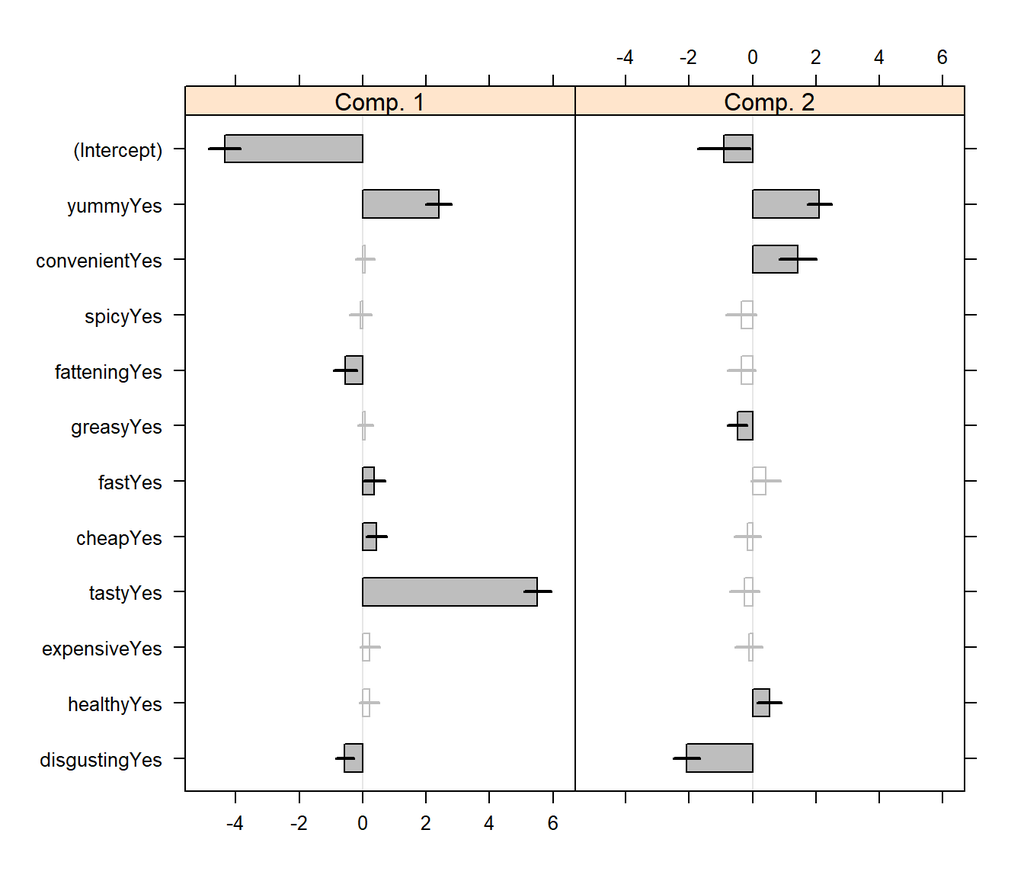

Fig 8

```r
plot(MD_ref2, significance = TRUE)
```

Figure 8 shows regression coefficients in dark grey if the corresponding estimate is significant. The default significance level is α = 0.05, and multiple testing is not accounted for. Insignificant coefficients are light grey. The horizontal lines at the end of the bars give a 95% confidence interval for each regression coefficient of each segment.

We interpret Fig.8 as follows:

- Members of segment 1 (component 1) like McDonald’s if they perceive it as yummy, fast, cheap and tasty, but not fattening and disgusting.
- For members of segment 1, liking McDonald’s is not associated with their perception of whether eating at McDonald’s is convenient, and whether food served at McDonald’s is healthy.
- In contrast, perceiving McDonald’s as convenient and healthy is important to segment 2 (component 2).

Using the perception of healthy as an example:

If segment 2 is targeted, it is important for McDonald’s to convince segment members that McDonald’s serves (at least some) healthy food items.

The health argument is unnecessary for members of segment 1. Instead, this segment wants to hear about how good the food tastes, and how fast and cheap it is.

## 6. Step 6: Profiling Segments

The core of the segmentation analysis is complete: market segments have been extracted. Now we need to understand what the four-segment k-means solution means. The first step in this direction is to create a segment profile plot. The segment profile plot makes it easy to see key characteristics of each market segment. It also highlights differences between segments. To ensure the plot is easy to interpret, similar attributes should be positioned close to one another. We achieve this by calculating a hierarchical cluster analysis. Hierarchical cluster analysis used on attributes (rather than consumers) identifies – attribute by attribute – the most similar ones.

```r
MD_vclust <- hclust(dist(t(as.matrix(MD_x))))
```

The ordering of the segmentation variables identified by hierarchical clustering is then used (argument `which`) to create the segment profile plot. Marker variables are highlighted (shade = TRUE):

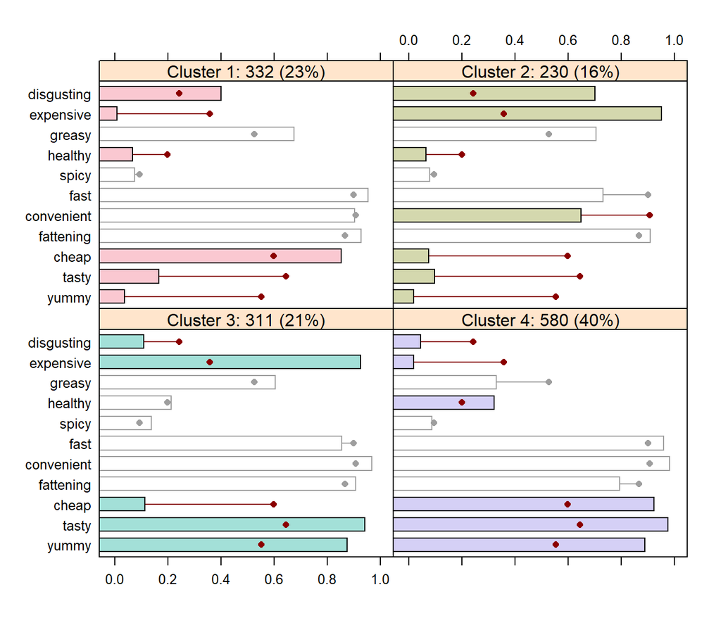

Fig 9

```r
barchart(MD_k4, shade = TRUE,
         which = rev(MD_vclust$order))
```

To understand the market segments, McDonald’s managers need to do two things:

1. compare the bars for each segment with the horizontal lines to see what makes each segment distinct from all consumers in the market
2. compare bars across segments to identify differences between segments.

Another visualisation that can help managers grasp the essence of market segments is the segment separation plot shown in Fig.10. The segment separation plot can be customised with additional arguments. We choose not to plot the hulls around the segments (hull = FALSE), to omit the neighbourhood graph (simlines = FALSE), and to label both axes (xlab, ylab):

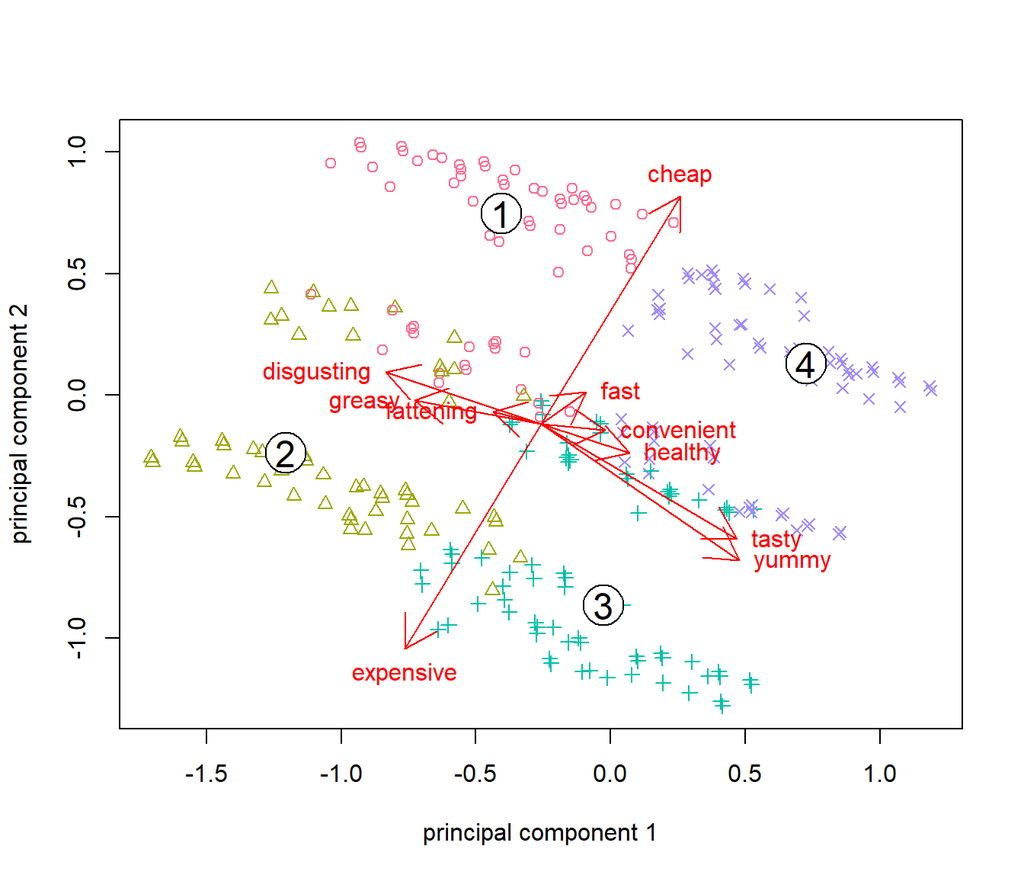

Fig 10

```r
plot(MD_k4, project = MD_pca, data = MD_x,
  hull = FALSE, simlines = FALSE,
  xlab = "principal component 1",
  ylab = "principal component 2")
projAxes(MD_pca)
```

Figure 10 looks familiar because we have already used principal components analysis to explore data in Step 4 (Fig.1). Here, the centres of each market segment are added using black circles containing the segment number. In addition, observations are coloured to reflect segment membership.

As can be seen, segments 1 and 4 both view McDonald’s as cheap, with members of segment 4 holding – in addition – some positive beliefs and members of segment 1 associating McDonald’s primarily with negative attributes. At the other end of the price spectrum, segment 2 agree that McDonald’s is not cheap, but disagree on other features with segment 2 holding a less flattering view than members of segment 3.

At the end of Step 6 McDonald’s managers have a good understanding of the nature of the four market segments in view of the information that was used to create these segments. Apart from that, they know little about the segments. Learning more about them is the key aim of Step 7.

## 7. Step 7: Describing Segments

The fast food data set is not typical for data collected for market segmentation analysis because it contains very few descriptor variables. Descriptor variables – additional pieces of information about consumers – are critically important to gaining a good understanding of market segments. One descriptor variable available in the fast food data set is the extent to which consumers love or hate McDonald’s. Using a simple mosaic plot, we can visualise the association between segment membership and loving or hating McDonald’s.

To do this, we first extract the segment membership for each consumer for the four-segment solution. Next we cross-tabulate segment membership and the love- hate variable. Finally, we generate the mosaic plot with cells colours indicating the deviation of the observed frequencies in each cell from the expected frequency if variables are not associated (shade = TRUE). We do not require a title for our mosaic plot (main = ""), but we would like the x-axis to be labelled (xlab):

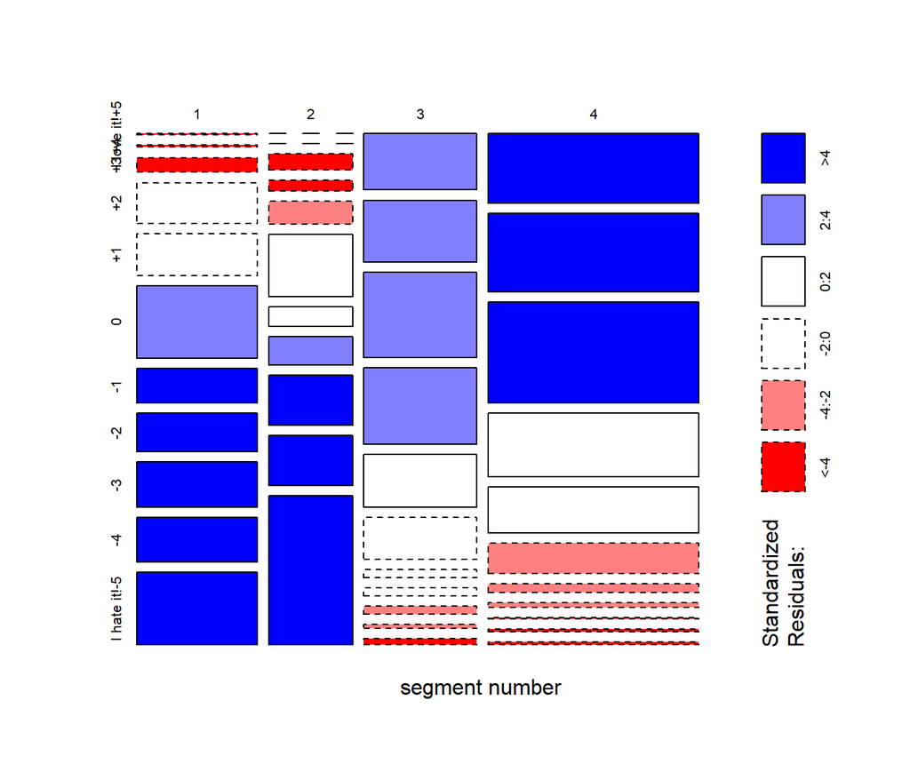

Fig 11

```r
k4 <- clusters(MD_k4)
mosaicplot(table(k4, mcdonalds$Like), shade = TRUE, main = "",
  xlab = "segment number")
```

The mosaic plot in Fig.A.11 plots segment number along the x-axis, and loving or hating McDonald’s along the y-axis. The mosaic plot reveals a strong and significant association between those two variables. Members of segment 1 (depicted in the first column) rarely express love for McDonald’s, as indicated by the top left boxes being coloured in red. In stark contrast, members of segment 4 are significantly more likely to love McDonald’s (as indicated by the dark blue boxes in the top right of the mosaic plot). At the same time, these consumers are less likely to hate McDonald’s (as indicated by the very small red boxes at the bottom right of the plot). Members of segment 2 appear to have the strongest negative feelings towards McDonald’s; their likelihood of hating McDonald’s is extremely high (dark blue boxes at the bottom of the second column), and nearly none of the consumers in this segment love McDonald’s (tiny first and second box at the top of column two, then dark red third and fourth box). The fast food data contains a few other basic descriptor variables, such as gender and age. Figure 12 shows gender distribution across segments. We generate this figure using the command:

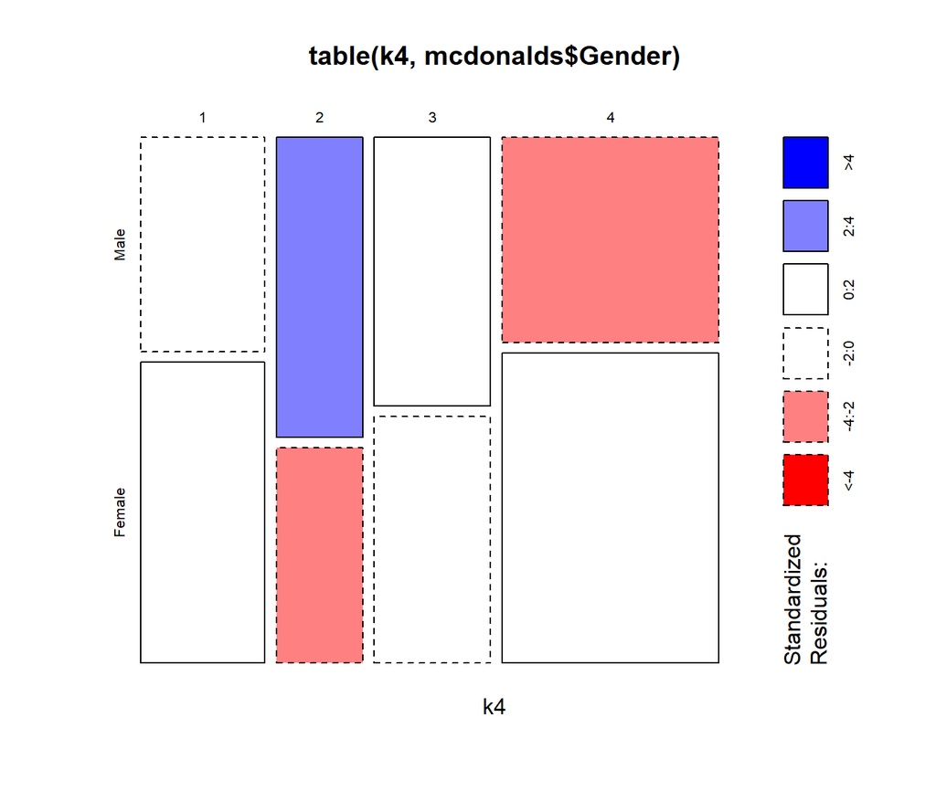

Fig 12

```r
mosaicplot(table(k4, mcdonalds$Gender), shade = TRUE)
```

Market segments are plotted along the x-axis. The descriptor variable (gender) is plotted along the y-axis. The mosaic plot offers the following additional insights about our market segments: segment 1 and segment 3 have a similar gender distribution as the overall sample. Segment 2 contains significantly more men (as depicted by the larger blue box for the category male, and the smaller red box for the category female in the second column of the plot). Members of segment 4 are significantly less likely to be men (smaller red box at the top of the fourth column). Because age is metric – rather than categorical – we use a parallel box-and- whisker plot to assess the association of age with segment membership. We generate Fig.A.13 using the R command:

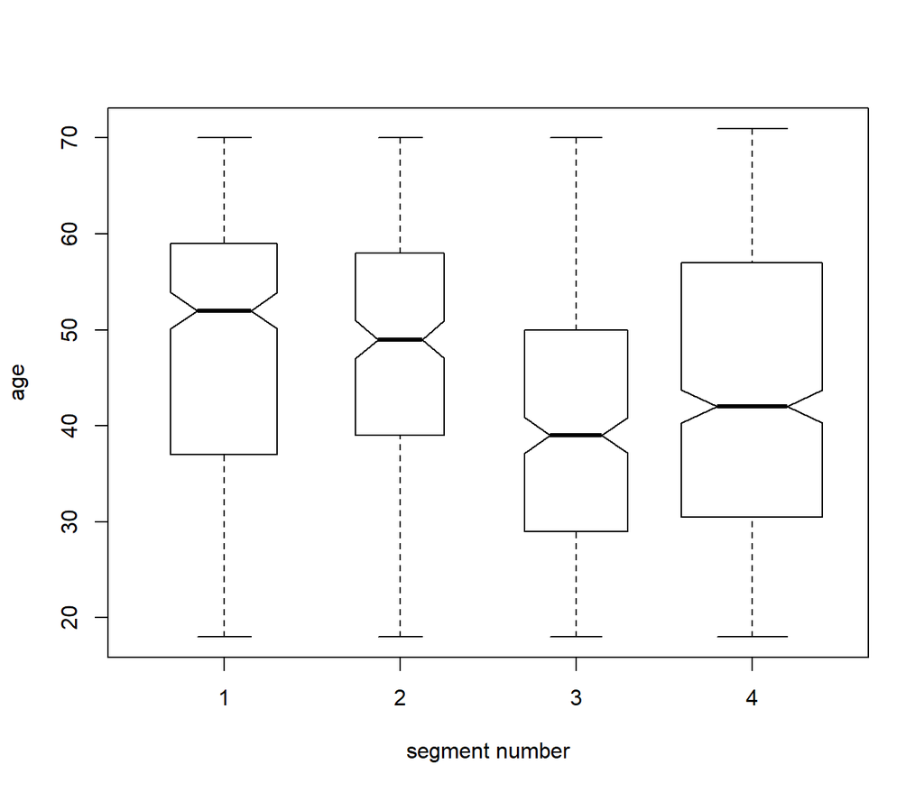

Fig 13

```r
boxplot(mcdonalds$Age ~ k4, varwidth = TRUE, notch = TRUE,
  xlab = "segment number", ylab = "age")
```

To further characterise market segments with respect to the descriptor variables, we try to predict segment membership using descriptor variables. We do this by fitting a conditional inference tree with segment 3 membership as dependent variable, and all available descriptor variables as independent variables:

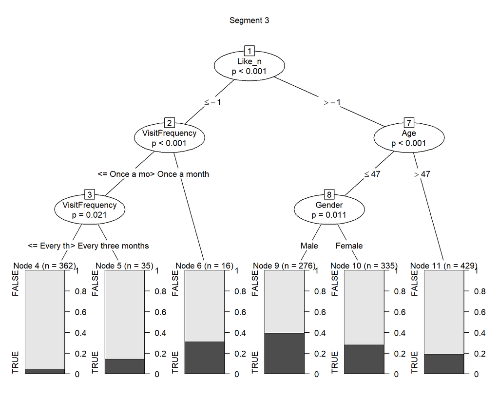

Fig 14

```r
library("partykit")
set.seed(SEED)
tree <- ctree(
  factor(k4 == 3) ~ Like_n + Age + VisitFrequency + Gender,
  data = mcdonalds)
plot(tree,"Segment 3")
```

Figure 14 shows the resulting classification tree. The independent variables used in the tree are LIKE_N, AGE, VISIT_FREQUENCY and GENDER. The tree indicates that respondents who like (>-1) McDonald’s, and are young (node 9 and 10), or do not like McDonald’s, but visit it more often than once a month (node 6), have the highest probability to belong to segment 3. In contrast, respondents visit McDonald’s once a month at most (node 4 & 5), are almost certainly not members of segment 3.

Optimally, additional descriptor variables would be available. Of particular interest would be information about product preferences, frequency of eating at a fast food restaurant, frequency of dining out in general, hobbies and frequently used information sources (such as TV, radio, newspapers, social media). The availability of such information allows the data analyst to develop a detailed description of each market segment. A detailed description, in turn, serves as the basis for tasks conducted in Step 9 where the perfect marketing mix for the selected target segment is designed.

## 8. Step 8: Selecting (the) Target Segment(s)

Using the knock-out criteria and segment attractiveness criteria specified in Step 2, users of the market segmentation (McDonald’s managers) can now proceed to develop a segment evaluation plot.

The segment evaluation plot in Fig.A.15 is extremely simplified because only a small number of descriptor variables are available for the fast food data set. In Fig.A.15 the frequency of visiting McDonald’s is plotted along the x-axis. The extent of liking or hating McDonald’s is plotted along the y-axis. The bubble size represents the percentage of female consumers.

We can obtain the values required to construct the segment evaluation plot using thefollowing commands. First, we compute the mean value of the visiting frequency of McDonald’s for each segment.

First we create a table with the cluster assignment added to the raw table.

```r
mcdonalds %>%
  # add the cluster solution column
  add_column(k4) -> macd_k4
head(macd_k4,3)
```

|  | yummy | convenient | spicy | fattening | greasy | fast | cheap | tasty | expensive | healthy | disgusting | Like | Age | VisitFrequency | Gender | Like_n | k4 |
| --- | --- | --- | --- | --- | --- | --- | --- | --- | --- | --- | --- | --- | --- | --- | --- | --- | --- |
| 1 | No | Yes | No | Yes | No | Yes | Yes | No | Yes | No | No | -3 | 61 | Every three months | Female | -3 | 1 |
| 2 | Yes | Yes | No | Yes | Yes | Yes | Yes | Yes | Yes | No | No | +2 | 51 | Every three months | Female | 2 | 3 |
| 3 | No | Yes | Yes | Yes | Yes | Yes | No | Yes | Yes | Yes | No | +1 | 62 | Every three months | Female | 1 | 3 |

Then we calculate the average visit frequency for each segment.

```r
# Visit
macd_k4 %>%
  # VisitFrequency is a factor of survey response, the ordinal is the visit count
  mutate(visit_count = as.numeric(VisitFrequency)) %>%
  group_by(k4) %>%
  summarise(visit = mean(visit_count)) -> visit

visit
```

| k4 | visit |
| --- | --- |
| 1 | 2.587349 |
| 2 | 2.460870 |
| 3 | 3.864952 |
| 4 | 3.946552 |

```r
macd_k4 %>%
  # Like_n = +5 "I Love MacD!" -5 "I Hate MacD!"
  group_by(k4) %>%
  summarise(like = mean(Like_n)) -> like

like
```

| k4 | like |
| --- | --- |
| 1 | -1.478916 |
| 2 | -2.639130 |
| 3 | 2.189711 |
| 4 | 2.665517 |

We need to convert the variable GENDER to numeric before computing mean segment values:

```r
macd_k4 %>%
  # Gender Female
  group_by(k4) %>%
  summarise(female = mean(Gender=="Female")) -> female

female
```

| k4 | female |
| --- | --- |
| 1 | 0.5843373 |
| 2 | 0.4173913 |
| 3 | 0.4790997 |
| 4 | 0.6017241 |

Now we can create the segment evaluation plot using the following commands:

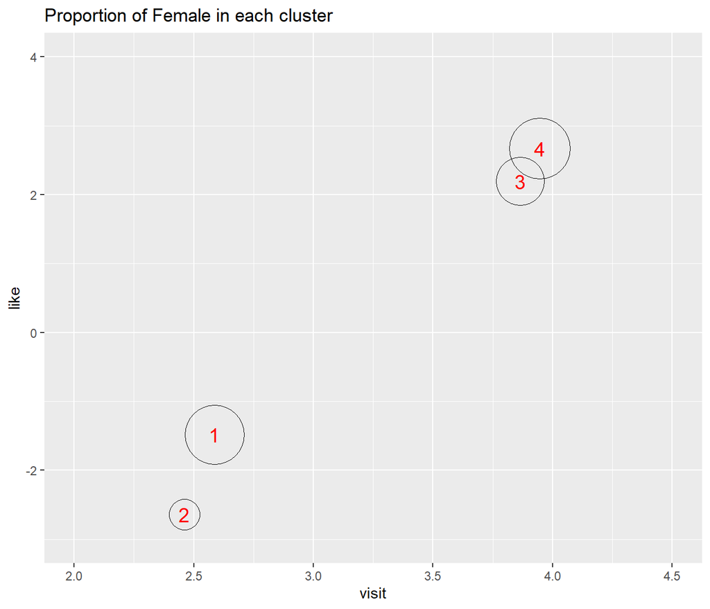

Fig 15

```r
# join 3 tables visit, like and female
visit %>%
  inner_join(like) %>%
  inner_join(female) %>%
  # Plot
  ggplot(aes(x=visit, y=like,
             size=female, # Proportion of female
             label=k4)) + # Cluster assignment
  geom_point(shape=21) +
  geom_text(color="red", size=5) +
  scale_size_continuous(range = c(10, 20)) + # Adjust size of min max circles
  scale_x_continuous(limits=c(2,4.5)) +      # Set limits of x and y axis
  scale_y_continuous(limits=c(-3,4)) +
  theme(legend.position = "none") +          # No legend
  ggtitle("Proportion of Female in each cluster")
```

Size of circles is controlled by `scale_size_continuous(range = c(10, 20))` arguments 10 and 20 is found by experimentation. `scale_x_continuous` and `scale_y_continuous` with arguments `limits` specify the ranges for the axes.

The segment evaluation plot serves as a useful decision support tool for McDon- ald’s management to discuss which of the four market segments should be targeted and, as such, become the focus of attention in Step 9.

## 9. Step 9: Customising the Marketing Mix

In Step 9 the marketing mix is designed. If, for example, McDonald’s managers decide to focus on segment 3 (young customers who like McDonald’s, think the food is yummy and tasty, but perceive it as pretty expensive), they could choose to offer a MCSUPERBUDGET line to cater specifically to the price expectations of this segment (4Ps: Price). The advantage of such an approach might be that members of segment 3 develop to become loyal customers who, as they start earning more money, will not care about the price any more and move to the regular McDonald’s range of products. To not cannibalise the main range, the product features of the MCSUPERBUDGET range would have to be distinctly different (4Ps: Product). Next, communication channels would have to be identified which are heavily used by members of segment 3 to communicate the availability of the MCSUPERBUDGET line (4Ps: Promotion). Distribution channels (4Ps: Place) would have to be the same given that all McDonald’s food is sold in McDonald’s outlets. But McDonald’s management could consider having a MCSUPERBUDGET lane where the wait in the queue might be slightly longer in an attempt not to cannibalise the main product line.

## 10. Step 10: Evaluation and Monitoring

After the market segmentation analysis is completed, and all strategic and tactical marketing activities have been undertaken, the success of the market segmentation strategy has to be evaluated, and the market must be carefully monitored on a continuous basis. It is possible, for example, that members of segment 3 start earning more money and the MCSUPERBUDGET line is no longer suitable for them. Changes can occur within existing market segments. But changes can also occur in the larger marketplace, for example, if new competitors enter the market. All potential sources of change have to be monitored in order to detect changes which require McDonald’s management to adjust their strategic or tactical marketing in view of new market circumstances.